# HW5 - Concrete

Mike Lehman

October 17, 2016

## Introduction

The goal of this assessment is to apply an Artificial Neural Network (ANN) model to a set a numeric data to predict the value of an additional numeric parameter. More generally, ANNs can be used in multiple machine learning environments and use cases. ANNs can be used in classification tasks as well predciting both linear and non-linear continuous variables. In fact, ANNs are well suited to working with highly non-linear relationships which we will soon see.

For this assessment we will be using an ANN to assess the compressive strength of concrete given a discrete set of numeric input variables.

## Data Collection and Preparation

The original concrete data set is available at the [UCI Machine Learning Repository](https://archive.ics.uci.edu/ml/datasets/Concrete+Compressive+Strength). At this location follow the Data Folder link to find the original data set. The original data set is an .xslx file that contains detailed column names as to what the numbers in the table represent.

For example, we can see nine total features, including the one for which we are testing, Concrete compressive strength which is expressed in units of megapascals (MPa). Reading right-to-left starting with the compressive strength column, the next variable is age, easily understood in terms of days.

Next, we can see that all other features are expressed in units of kilograms per cubic meter. The rest of the features are ingredients found in the concrete mixture: cement, blast furnace slag, fly ash, water, superplasticizer, coarse aggregate, and fine aggregate. It is important to acquire this domain specific knowledge about the data, as the cleansed data set we will use provides only name descriptions with numeric values and not any units of measure.

It is also important to note, based on the readme file which is found in the same directory of the .xlsx file, that the values in the data set are in raw form and not scaled. This will play an important role in our data preparation as we look towards building our ANN.

We’ll begin by reading the cleansed data from the concrete.csv file:

```r
concrete <- read.csv("concrete.csv")
str(concrete)
```

```
## 'data.frame':    1030 obs. of  9 variables:
##  $ cement      : num  141 169 250 266 155 ...
##  $ slag        : num  212 42.2 0 114 183.4 ...
##  $ ash         : num  0 124.3 95.7 0 0 ...
##  $ water       : num  204 158 187 228 193 ...
##  $ superplastic: num  0 10.8 5.5 0 9.1 0 0 6.4 0 9 ...
##  $ coarseagg   : num  972 1081 957 932 1047 ...
##  $ fineagg     : num  748 796 861 670 697 ...
##  $ age         : int  28 14 28 28 28 90 7 56 28 28 ...
##  $ strength    : num  29.9 23.5 29.2 45.9 18.3 ...
```

We can see the same values as those found in the original data set, but with brief names that correspond to the columns seen in the original data set.

The first problem we encounter is that many of the variables have large ranges in values:

```r
summary(concrete)
```

```
##      cement           slag            ash             water
##  Min.   :102.0   Min.   :  0.0   Min.   :  0.00   Min.   :121.8
##  1st Qu.:192.4   1st Qu.:  0.0   1st Qu.:  0.00   1st Qu.:164.9
##  Median :272.9   Median : 22.0   Median :  0.00   Median :185.0
##  Mean   :281.2   Mean   : 73.9   Mean   : 54.19   Mean   :181.6
##  3rd Qu.:350.0   3rd Qu.:142.9   3rd Qu.:118.30   3rd Qu.:192.0
##  Max.   :540.0   Max.   :359.4   Max.   :200.10   Max.   :247.0
##   superplastic      coarseagg         fineagg           age
##  Min.   : 0.000   Min.   : 801.0   Min.   :594.0   Min.   :  1.00
##  1st Qu.: 0.000   1st Qu.: 932.0   1st Qu.:731.0   1st Qu.:  7.00
##  Median : 6.400   Median : 968.0   Median :779.5   Median : 28.00
##  Mean   : 6.205   Mean   : 972.9   Mean   :773.6   Mean   : 45.66
##  3rd Qu.:10.200   3rd Qu.:1029.4   3rd Qu.:824.0   3rd Qu.: 56.00
##  Max.   :32.200   Max.   :1145.0   Max.   :992.6   Max.   :365.00
##     strength
##  Min.   : 2.33
##  1st Qu.:23.71
##  Median :34.45
##  Mean   :35.82
##  3rd Qu.:46.13
##  Max.   :82.60
```

ANN’s work best when input values are sclaed to a small range, typically around zero. We can scale our data by creating a custom normalize functions which applies a basic min-max normalization:

```r
normalize <- function(x) {
  return((x - min(x)) / (max(x) - min(x)))
}
```

Now that we have our custom function, we can apply it to every value in each column of the data frame:

```r
concrete_norm <- as.data.frame(lapply(concrete, normalize))
summary(concrete_norm$strength)
```

```
##    Min. 1st Qu.  Median    Mean 3rd Qu.    Max.
##  0.0000  0.2664  0.4001  0.4172  0.5457  1.0000
```

```r
summary(concrete$strength)
```

```
##    Min. 1st Qu.  Median    Mean 3rd Qu.    Max.
##    2.33   23.71   34.44   35.82   46.14   82.60
```

The summary differences between the two data sets’ taget variables show how the range has been reduced to between zero and one. This will make our ANN much more accurate with regards to predicting the target feature and dealing with the inputs.

Finally, we will subset the data into train and test sets by a 75/25 split. Based on the description of the original data set, the data are already randomly ordered, so we can simply subset by current rows:

```r
concrete_train <- concrete_norm[1:773, ]
concrete_test <- concrete_norm[774:1030, ]
```

## Train Model

To train our model we will make use of the neuralnet R library which allows for creation of ANNs in a similar method to constructing other machine learning objects such as linear and non-linear regressions and regression trees.

We will also set a seed value so that our results can be reproduced as much as possible:

```r
library(neuralnet)
set.seed(12345)
```

To build our model we will pass our features (dependent and independent) to the neuralnet function and specify our train data set.

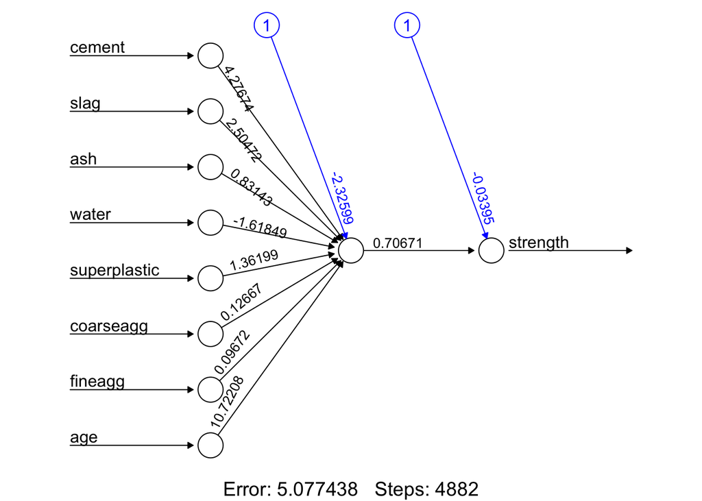

```r
concrete_model <- neuralnet(formula = strength ~ cement + slag + ash + water + superplastic
                            + coarseagg + fineagg + age, data = concrete_train)
plot(concrete_model, rep="best")
```

The plot of our ANN model shows that we have an ANN with an input layer, one hidden layer (with one hidden), and an output layer. In the input layer there are eight nodes, one for each independent feature in the data set. In the hidden layer, there is a single node.

When we created our ANN model, we did not specify a number of hidden nodes, so the neuralnet() function defaulted to 1. This will be covered in-depth in the next section as we assess and evaluate model performance.

The output layer contains a single node with our dependent target feature.

There are a number of other details here that provide additional information about our ANN model. First, observe the line that connects each input feature node to the hidden layer node. Along these lines are various numbers. These numbers represent the weights for each of the connections.

In short, the weight of a connection between the input and hidden layers in an ANN is a function of backpropagation. Before discussing backpropagation in detail, the weight of a feature can be considered as a modifier for that feature. The given value for the input feature is multiplied by the weight. The weighted inputs are then used in conjunction with the hidden node’s activation functions to determine the output value.

Backpropagation refers to a technique similar to finding the gradient of a linear model. The ANN determines what it should have produced as a response and uses the difference between the desired and actual response to adjust the weights and threshold values of each hidden layer neuron so that next time the error in response will be less for the same inputs.

The backpropagation process continues for each set of inputs and corresponding outputs so long as the total errors or responses exceed a specified level or until there are no measureable errors.

Since we have covered ANN layers and the process of backpropagation, it is also worthwhile to take time to consider other features of ANNs, such as bias and activation functions.

Looking at the plot of our model, we can see two nodes outside the flow of the ANN with 1’s and lines pointing toward the hidden and output neurons with values along the lines. These are the bias terms and they are numeric constants that allow the value of the indicated nodes to be shifted upward or downward. The idea is similar to the intercept of a linear equation. These constant values are not impacted by the values passed from the previous layer. This allows us to better match models where the activation functions may not perfectly model the relationships within the data.

In the same way we would want to move the line in a linear model vertically along the y-axis, we can adjust the position of our activation function to better model the actual relationships in the data. Going back to linear models, the line of best fit may not always pass through x = 0, y = 0, and bias terms in ANNs help to model similar differences.

Activation functions are the mechanisms that determine how information passes throughout the ANN at each neuron. These functions take the input values and transform them based on a set of criteria and determine the optimal output value. There are a number of different types of activation functions, the selection of which can bias ANNs in certain ways.

The most common activation function is the sigmoid activation function which allows for non-binary outputs where the output value can fall anywhere in the range from 0 to 1. This can cause problems where there is a dynamic range of input values with many very high or low values resulting in a narrow output between 0 and 1. This is referred to as the squashing problem and is shared by many different ANN function types.

Recall that prior to training our model we normalized our numeric values such that they range between 0 and 1. This is the solution to the squashing problem, to limit the range of input values such that the resulting output does not skew predicted values.

## Evaluating Model Performance

To evalute our model’s performance, we will create a new object to hold the results of passing our model and the entire test data set, minus the target feature: strength.

This creates a neuralnet() list object that contains two items: neurons (another list) and a numeric set - net.result.

```r
model_results <- compute(concrete_model, concrete_test[1:8])
predicted_strength <- model_results$net.result
```

The predicted_strength object contains the net.result values from our model results object. To assess performance we will pass this set of values to R’s cor() function along with out test data set’s target feature values to determine the degree of correlation between our predicted and actual values:

```r
cor(predicted_strength, concrete_test$strength)
```

```
##              [,1]
## [1,] 0.8064655576
```

The output shows that our correlation value is close to 1. Correlation values close to 1 indicate a strong linear relationship, which means that our model is quite successful with only using one hidden node.

## Improving Model Performance

Since our model performed quite well with using only one hidden node, it is likely that by increasing the number of hidden nodes, that we may be able to achieve a greater correltion value. To do so we will create a second model and first plot the results:

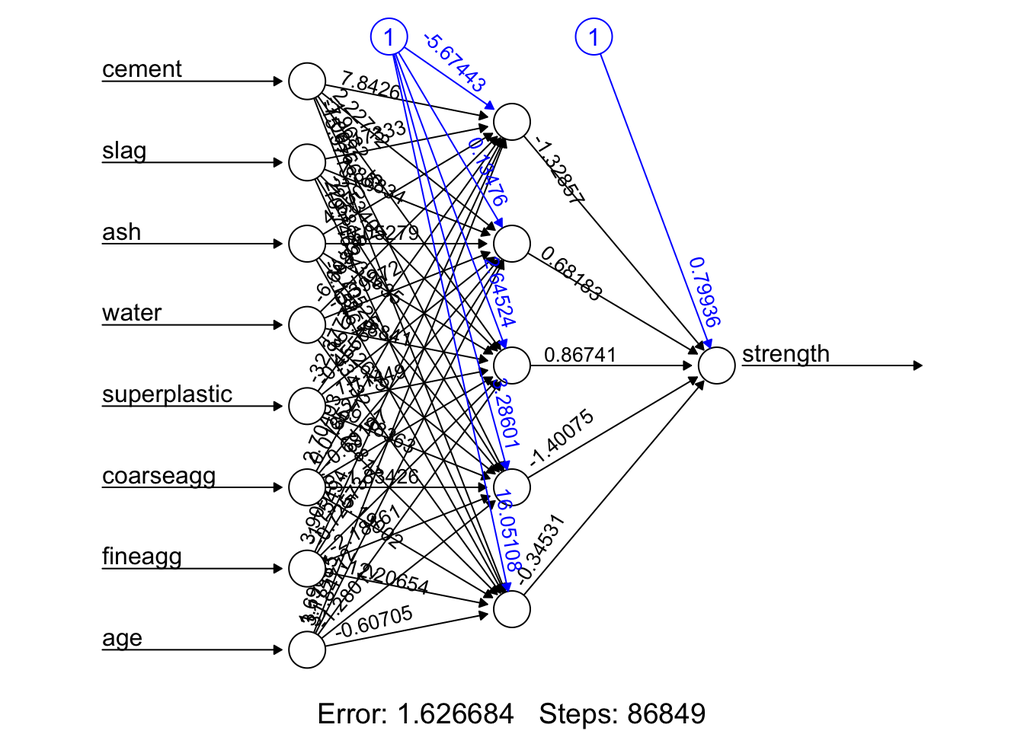

```r
set.seed(12345)
# create ANN model with 5 hidden neurons
concrete_model2 <- neuralnet(strength ~ cement + slag +
                               ash + water + superplastic +
                               coarseagg + fineagg + age,
                             data = concrete_train, hidden = 5)
plot(concrete_model2, rep="best")
```

When we created out second model, we only had to pass an additional parameter: hidden, with a value of five to increase the number of hidden nodes in our model.

From the plot, we can see that our sum of squared errors reduced quite a bit compared to the original model, and the number of steps greatly increased, which makes sense given the greater complexity of the model.

To evaluate our results, we will use the same procedure as before:

```r
model_results2 <- compute(concrete_model2, concrete_test[1:8])
predicted_strength2 <- model_results2$net.result
cor(predicted_strength2, concrete_test$strength)
```

```
##              [,1]
## [1,] 0.9244533426
```

Our correlation value moved even closer to 1, meaning that our model is quite close to finding an exact perfect linear pattern to matches our input values to our expected outout values.

Since five hidden nodes improved our model so much, let’s see if using ten hidden nodes can get us even closer:

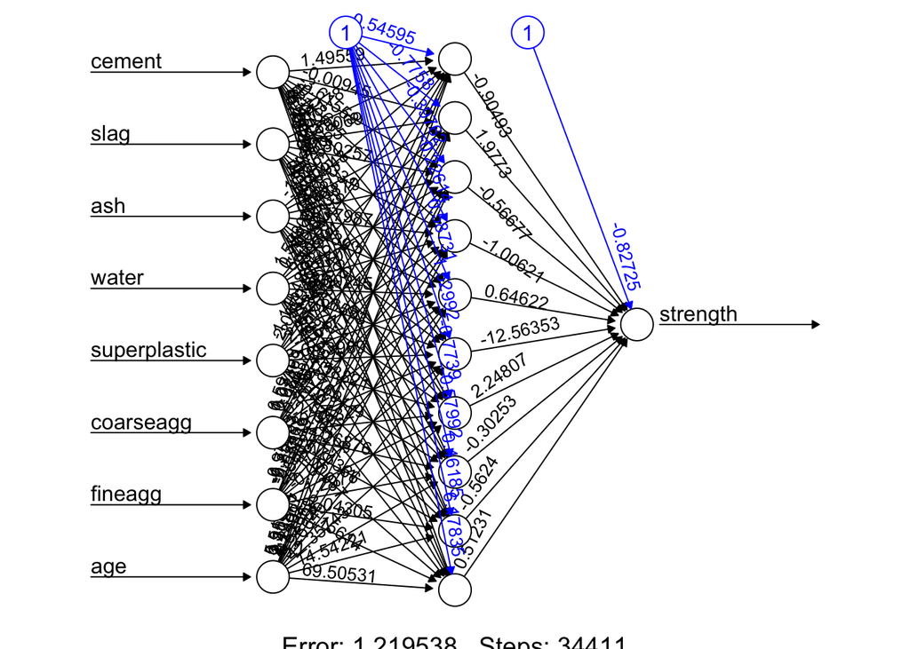

```r
set.seed(12345)
concrete_model3 <- neuralnet(strength ~ cement + slag +
                               ash + water + superplastic +
                               coarseagg + fineagg + age,
                             data = concrete_train, hidden = 10)
plot(concrete_model3, rep="best")
```

```r
model_results3 <- compute(concrete_model3, concrete_test[1:8])
predicted_strength3 <- model_results3$net.result
cor(predicted_strength3, concrete_test$strength)
```

```
##              [,1]
## [1,] 0.9363509159
```

Our correlation value did get closer to 1, but only by a smaller amount. Additionally, our sum of squared errors decreased, and interestingly the steps in the ANN decreased. However, our gains were modest and given that this third model is more computationally expensive, it is probably not worth considering the increase in hidden nodes.

For one final improvement, we can increase the not only the number of hidden nodes, but also the number of hidden layers. An ANN model with more than one hidden layer is oftern referred to as a deep learning model. To add a hidden layer we simply pass multiple hidden values to the neuralnet() function, with each value adding a new hidden layer:

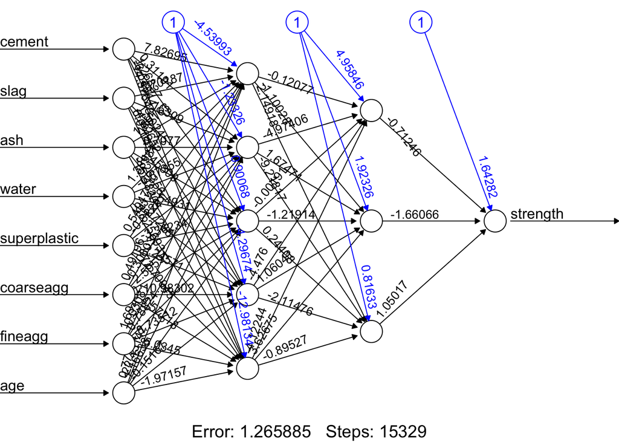

```r
set.seed(12345)
concrete_model4 <- neuralnet(strength ~ cement + slag +
                               ash + water + superplastic +
                               coarseagg + fineagg + age,
                             data = concrete_train, hidden=c(5,3))
plot(concrete_model4, rep="best")
```

```r
model_results4 <- compute(concrete_model4, concrete_test[1:8])
predicted_strength4 <- model_results4$net.result
cor(predicted_strength4, concrete_test$strength)
```

```
##              [,1]
## [1,] 0.9290962198
```

## Conclusion

Artificial neural networks are very powerful “black-box” models for machine learning. ANNs are able to handle tasks for classifications as well as prediction of continuous variables. Although the underlying math can be dense and difficult to parse, various R packages allow for easy construction of ANNs.

Often linear and logistic (non-linear) regression models are able to match if not exceed the performance of ANNs; however, regression models require much more effort to build and train, whereas ANNs can model linearities and non-linearities automatically, with little up-front effort required.

As we saw with our models, a simple ANN with only one hidden layer containing one hidden node oftern performs quite well. We saw significant performance gains with the addition of four more hidden nodes, but saw only modest improvements when adding more hidden nodes and layers.

In addition to only modest performance gains, adding more hidden nodes and layers can easily lead to overfitting and prevent our model from scaling to unseen data.

With such accuracy easily achieved with only a few R functions, one can see how useful ANNs can be for continuous prediction. Tackling the same problem with a linear or logisitc model would have required much more effort and manual steps.

R Source